# Iris data analysis

By Erik Boström

“iris”" is a predefined dataframe available within R. It is a probably the most known dataset available for testing, first analyzed in Fisher (1936). It contains the length and width of measurements from three different iris species “Setosa”, “Versicolor” and “Virginica”.

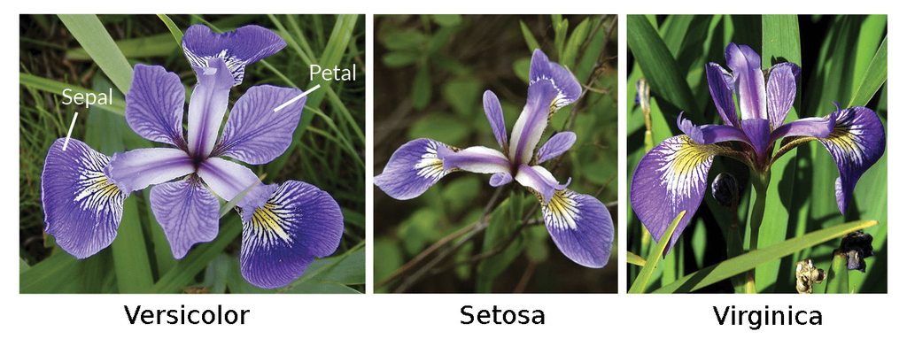

```r
str(iris)
```

```
'data.frame':   150 obs. of  5 variables:
 $ Sepal.Length: num  5.1 4.9 4.7 4.6 5 5.4 4.6 5 4.4 4.9 ...
 $ Sepal.Width : num  3.5 3 3.2 3.1 3.6 3.9 3.4 3.4 2.9 3.1 ...
 $ Petal.Length: num  1.4 1.4 1.3 1.5 1.4 1.7 1.4 1.5 1.4 1.5 ...
 $ Petal.Width : num  0.2 0.2 0.2 0.2 0.2 0.4 0.3 0.2 0.2 0.1 ...
 $ Species     : Factor w/ 3 levels "setosa","versicolor",..: 1 1 1 1 1 1 1 1 1 1 ...
```

There are 50 samples each for each of the species:

```r
#iris$Species <- as.character(iris$Species)
table(iris$Species)
```

```
    setosa versicolor  virginica
        50         50         50
```

```r
summary(iris[iris$Species=="setosa",])
```

```
  Sepal.Length    Sepal.Width     Petal.Length    Petal.Width          Species
 Min.   :4.300   Min.   :2.300   Min.   :1.000   Min.   :0.100   setosa    :50
 1st Qu.:4.800   1st Qu.:3.200   1st Qu.:1.400   1st Qu.:0.200   versicolor: 0
 Median :5.000   Median :3.400   Median :1.500   Median :0.200   virginica : 0
 Mean   :5.006   Mean   :3.428   Mean   :1.462   Mean   :0.246
 3rd Qu.:5.200   3rd Qu.:3.675   3rd Qu.:1.575   3rd Qu.:0.300
 Max.   :5.800   Max.   :4.400   Max.   :1.900   Max.   :0.600
```

```r
summary(iris[iris$Species=="versicolor",])
```

```
  Sepal.Length    Sepal.Width     Petal.Length   Petal.Width          Species
 Min.   :4.900   Min.   :2.000   Min.   :3.00   Min.   :1.000   setosa    : 0
 1st Qu.:5.600   1st Qu.:2.525   1st Qu.:4.00   1st Qu.:1.200   versicolor:50
 Median :5.900   Median :2.800   Median :4.35   Median :1.300   virginica : 0
 Mean   :5.936   Mean   :2.770   Mean   :4.26   Mean   :1.326
 3rd Qu.:6.300   3rd Qu.:3.000   3rd Qu.:4.60   3rd Qu.:1.500
 Max.   :7.000   Max.   :3.400   Max.   :5.10   Max.   :1.800
```

```r
summary(iris[iris$Species=="virginica",])
```

```
  Sepal.Length    Sepal.Width     Petal.Length    Petal.Width          Species
 Min.   :4.900   Min.   :2.200   Min.   :4.500   Min.   :1.400   setosa    : 0
 1st Qu.:6.225   1st Qu.:2.800   1st Qu.:5.100   1st Qu.:1.800   versicolor: 0
 Median :6.500   Median :3.000   Median :5.550   Median :2.000   virginica :50
 Mean   :6.588   Mean   :2.974   Mean   :5.552   Mean   :2.026
 3rd Qu.:6.900   3rd Qu.:3.175   3rd Qu.:5.875   3rd Qu.:2.300
 Max.   :7.900   Max.   :3.800   Max.   :6.900   Max.   :2.500
```

The different species differ significantly in length, especially the petal:

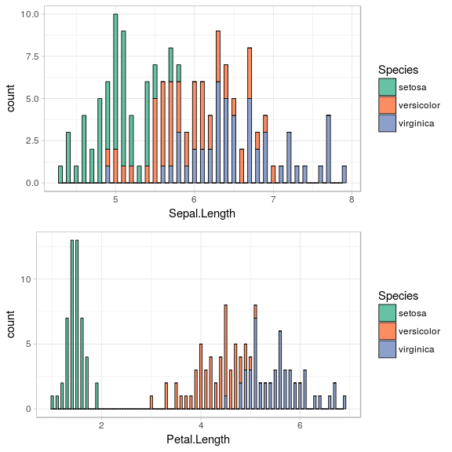

```r
library(ggplot2)
p   <- "Set2"
sfb <- scale_fill_brewer(palette=p)
t   <- theme_light()
p1 <- ggplot(iris, aes(x=Sepal.Length, fill=Species)) + geom_histogram(color="black",size=0.3,binwidth=0.05) + sfb + t
p2 <- ggplot(iris, aes(x=Petal.Length, fill=Species)) + geom_histogram(color="black",size=0.3,binwidth=0.05) + sfb + t
grid.arrange(p1, p2, ncol=1)
```

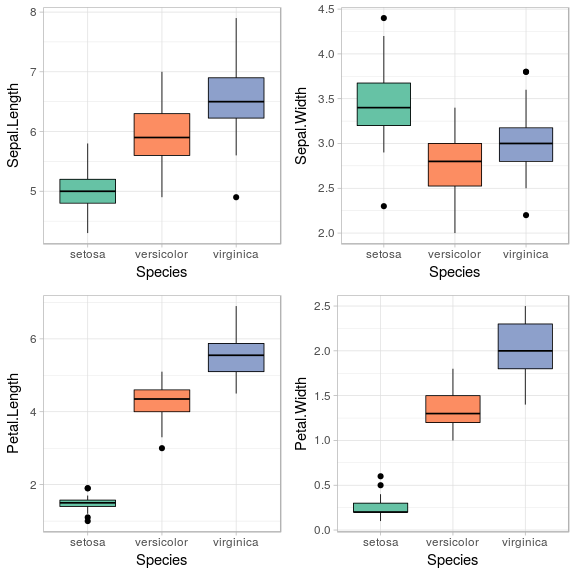

```r
require(gridExtra)
p1 <- ggplot(iris, aes(x=Species,y=Sepal.Length,fill=Species))  + geom_boxplot(color="black",size=0.3,show.legend = FALSE) + sfb + t
p2 <- ggplot(iris, aes(x=Species,y=Sepal.Width, fill=Species))  + geom_boxplot(color="black",size=0.3,show.legend = FALSE) + sfb + t
p3 <- ggplot(iris, aes(x=Species,y=Petal.Length, fill=Species)) + geom_boxplot(color="black",size=0.3,show.legend = FALSE) + sfb + t
p4 <- ggplot(iris, aes(x=Species,y=Petal.Width, fill=Species))  + geom_boxplot(color="black",size=0.3,show.legend = FALSE) + sfb + t
grid.arrange(p1, p2, p3, p4, ncol=2)
```

[figure not shown]

```r
scb = scale_color_brewer(palette=pal)
p1 <- ggplot(iris,aes(x=Sepal.Length,y=Sepal.Width)) + geom_point(aes(color=Species),size=2) + scb + t
p2 <- ggplot(iris,aes(x=Petal.Length,y=Petal.Width)) + geom_point(aes(color=Species),size=2) + scb + t
grid.arrange(p1, p2, ncol=1)
```

## Machine learning

We want to predict the Species based on input measurements of the sepal and petal lengths and widths.

```r
set.seed(1234)
```

To index elements to test and trial sets, construct a random vector of the same size as the datasets with values of either 0 or 1 randomly distributed, 0 to a training set (2/3 of the dataset), and 1 to a test set (1/3 of the dataset).

```r
I <- sample(c(0,1), nrow(iris), replace=TRUE, prob=c(2/3, 1/3))
prop.table(table(I))
```

```
I
        0         1
0.6733333 0.3266667
```

Construct training and test sets

```r
iris.train        <- iris[I==0,1:4]
iris.train_full   <- iris[I==0,]
iris.train_labels <- iris[I==0,5]
iris.test         <- iris[I==1,1:4]
iris.test_full    <- iris[I==1,]
iris.test_labels  <- iris[I==1,5]
```

### k-NN – kth Nearest Neighbour

Let us now employ the simple k-NN algorithm to the training set

```r
library(class)
iris_knn <- knn(train=iris.train, test=iris.test, cl=iris.train_labels, k=3)
iris_knn
```

```
 [1] setosa     setosa     setosa     setosa
 [5] setosa     setosa     setosa     setosa
 [9] setosa     setosa     setosa     setosa
[13] setosa     setosa     setosa     setosa
[17] setosa     setosa     setosa     setosa
[21] setosa     versicolor versicolor versicolor
[25] versicolor versicolor versicolor versicolor
[29] versicolor versicolor versicolor versicolor
[33] versicolor versicolor virginica  virginica
[37] versicolor virginica  virginica  virginica
[41] virginica  virginica  virginica  virginica
[45] virginica  versicolor virginica  virginica
[49] virginica
Levels: setosa versicolor virginica
```

#### Validation

Compare to the test-data labels. Put evaluated labels side-by-side to the test-data labels.

```r
comp <- data.frame(iris_knn,data.frame(iris.test_labels))
names(comp) <- c("kNN predicted Species","Correct Species")
count <- 0
j <- 1
err <- 0
for(i in 1:length(comp[,1])){
  if (comp[i,1]==comp[i,2]){
    count = count + 1
    }else{
      err[j] <- i
      j <- j+1
    }
}
print(paste(count,"out of",length(comp[,1]),"predicted correctly! This is",100*count/length(comp[,1]), "percent correct."))
```

```
[1] "47 out of 49 predicted correctly! This is 95.9183673469388 percent correct."
```

The wrongly predicted quantities were

```r
comp[err,]
```

|  | kNN predicted Species | Correct Species |
| --- | --- | --- |
| 37 | versicolor | virginica |
| 46 | versicolor | virginica |

```r
library(gmodels)
CrossTable(x=iris.test_labels, y=iris_knn, prop.chisq = FALSE)
```

```
   Cell Contents
|-------------------------|
|                       N |
|           N / Row Total |
|           N / Col Total |
|         N / Table Total |
|-------------------------|


Total Observations in Table:  49


                 | iris_knn
iris.test_labels |     setosa | versicolor |  virginica |  Row Total |
-----------------|------------|------------|------------|------------|
          setosa |         21 |          0 |          0 |         21 |
                 |      1.000 |      0.000 |      0.000 |      0.429 |
                 |      1.000 |      0.000 |      0.000 |            |
                 |      0.429 |      0.000 |      0.000 |            |
-----------------|------------|------------|------------|------------|
      versicolor |          0 |         13 |          0 |         13 |
                 |      0.000 |      1.000 |      0.000 |      0.265 |
                 |      0.000 |      0.867 |      0.000 |            |
                 |      0.000 |      0.265 |      0.000 |            |
-----------------|------------|------------|------------|------------|
       virginica |          0 |          2 |         13 |         15 |
                 |      0.000 |      0.133 |      0.867 |      0.306 |
                 |      0.000 |      0.133 |      1.000 |            |
                 |      0.000 |      0.041 |      0.265 |            |
-----------------|------------|------------|------------|------------|
    Column Total |         21 |         15 |         13 |         49 |
                 |      0.429 |      0.306 |      0.265 |            |
-----------------|------------|------------|------------|------------|
```

### Conclusion

The kNN algoritm works suffently well on the iris data. A prediction of the seposa is perfect. This, due to the fact that it distinctly separates from the other two in both the sepal and petal data. On the other hand, there are overlap in the versicolor and virgicinca data which makes the classification of them harder. Despite this, the kNN did a rather accurate job in predicting them too with only 2 out of 28 prdictions wrong.

## Random forests

Random forests is a method that can be used to classify data and is about generation of a large number of decision trees.

```r
# Import the random forest package
library(randomForest)
# Compute the training
iris_randomforest <- randomForest(Species~ . , data=iris.train_full, ntree=100, mtry=2, importance=TRUE,proximity=TRUE)
iris_randomforest
```

```
Call:
 randomForest(formula = Species ~ ., data = iris.train_full, ntree = 100,      mtry = 2, importance = TRUE, proximity = TRUE)
               Type of random forest: classification
                     Number of trees: 100
No. of variables tried at each split: 2

        OOB estimate of  error rate: 6.93%
Confusion matrix:
           setosa versicolor virginica class.error
setosa         29          0         0  0.00000000
versicolor      0         34         3  0.08108108
virginica       0          4        31  0.11428571
```

Since the data contains more than one class (three) the data is *impure* (inhomogeneuous).

**Definition.** An *impurity measure* defines how well classes are separated.

The Gini impurity (named after the Italian statistician and sociologist Corrado Gini) is computed as follows
$$I_G = 1-\sum_{i=1}^J p_i^2,$$
where $J$ is the number of classes, and $\{p_i\}_{i=1}^J$ a set of individual probabilities

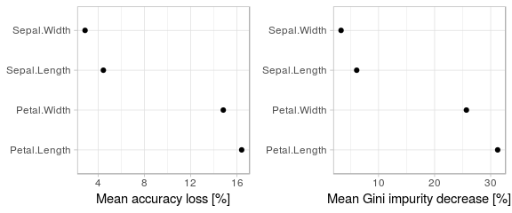

```r
imp <- varImpPlot(iris_randomforest)
graphics.off()
imp <- data.frame(imp)
p1 <- ggplot(imp,aes(y=row.names(imp),x=MeanDecreaseAccuracy)) + geom_point() + t + xlab("Mean accuracy loss [%]") + ylab(NULL)
p2 <- ggplot(imp,aes(y=row.names(imp),x=MeanDecreaseGini)) + geom_point() + t + xlab("Mean Gini impurity decrease [%]") + ylab(NULL)
grid.arrange(p1, p2, ncol=2)
```

Here the plots show the mean accuracy loss and the mean Gini impurity decrease when one of the four variables is removed from the training set. The decrease in Gini impurity shows how important that variable is to split the data correctly or in other words how “pure” the final node in the decision trees are. It is noticeable that the Petal data is weighted higher than the sepal data in the random forests algorithm. Now, let’s use the classifier

```r
prediction <- predict(iris_randomforest,iris.test_full)
table(observed=iris.test_labels, predicted=prediction)
```

```
            predicted
observed     setosa versicolor virginica
  setosa         21          0         0
  versicolor      0         13         0
  virginica       0          2        13
```

Thus, the result obtained is for this simple example dataset similar to the predicted result of the k-NN method. For both very good.

Fisher, Ronald A. 1936. “The Use of Multiple Measurements in Taxonomic Problems.” *Annals of Human Genetics* 7 (2). Wiley Online Library: 179–88.